# **Curso de Estadística básica para Data Scientists**

Dae-Jin Lee < lee.daejin@gmail.com >

TEMA 4. Variables Aleatorias y Probabilidad

[Regresar a la página principal](https://idaejin.github.io/datahack/)

# 1 Concepto de Variable Aleatoria

En ocasiones, describir todos los posibles resultados de un experimento aleatorio no es suficiente.

- Lanzar una moneda 3 veces: $\{(CCC), (CCX), ...\}$
- Lanzar un dado dos veces: $\{(1,1), (1,2), (1,3), ...\}$

A veces es útil asociar un número a cada resultado del experimento $\rightarrow$ Definir una variable

No conocemos el resultado del experimento antes de realizarlo

No conocemos el valor que va a tomar la variable antes del experimento

$\rightarrow$ **Variable Aleatoria**

*Ejemplo:*

- Lanzar una moneda 3 veces: $\{(CCC), (CCX), ...\}$
  $$X = \mbox{``Nº de Caras en el 1er lanzamiento $X[(CCC)]=1,X[(XCX)=0,...]$''}$$
- Lanzar un dado dos veces: $\{(1,1), (1,2), (1,3), ...\}$

$$Y = \mbox{``Suma de puntuaciones $Y[(1,1)]=2,Y[(1,2)]=3,...$''}$$

Una *variable aleatoria* es una función que asocia un número real a cada elemento del espacio muestral.

Las variables aleatorias se representan por letras mayúsculas, normalmente empezando por el final del alfabeto: X,Y, Z, etc.

Los posibles valores que puede tomar la variable se representan por letras minúsculas, ej: $x=1$ es un posible valor de la v.a. $X$.

**Ejemplos:**

- Número de unidades defectuosas en una muestra aleatoria de 5 unidades
- Número de defectos superficiales en un $cm^2$ de cierto material
- Tiempo de duración de una bombilla
- Resistencia a la compresión de un material de construcción

## 1.1 Variables aleatorias discretas y contínuas

El rango de una variable aleatoria es el conjunto de valores que puede tomar la variable.

Atendiendo al rango las variables se pueden clasificar como:

- Variables aleatorias discretas: Aquellas en las que el rango es finito infinito numerable.
- Variables aleatorias continuas: Aquellas en las que el rango es un intervalo de números reales.

### 1.1.1 Variables aleatorias discretas

Los valores de una variable aleatoria cambian de un experimento a otro al cambiar los resultados del experimento. Una variable aleatoria está definida por:

- los valores que toma
- la probabilidad de tomar cada uno esos valores

**Función de probabilidad** es una función que indica la probabilidad de cada valor

$$p(x_i) = P(X=x_i)$$

*Ejemplo:*

- Tiramos una moneda 3 veces. Representamos cara por c y cruz por z.
  $$W = \{ccc, ccz, czc, zcc, czz, zcz, zzc, zzz\}$$

*La probabilidad de cada suceso elemental es $1/8$. Por ejemplo $p(ccc)=1/8$, ya que la probabilidad de sacar cara en una tirada es $1/2$ según la definición clásica y las tiradas son independientes.*

*Definimos la v.a. X=número de caras, que puede tomar los valores {0, 1, 2, 3}. Se buscan todos los puntos muestrales que dan lugar a cada valor de la variable y a ese valor se le asigna la probabilidad del suceso correspondiente.*

| X | Sucesos | P(X=x) |
| --- | --- | --- |
| 0 | {zzz} | 1/8 |
| 1 | {czz, zcz, zzc} | 3/8 |
| 2 | {ccz, czc, zcc} | 3/8 |
| 3 | {ccc} | 1/8 |

En ocasiones nos puede interesar la probabilidad de que una variable tome un valor menor o igual que una cantidad (**Función de probabilidad**)

$$F_n(X) = P(X\leq x_n)$$

En ejemplo anterior:

| X | Sucesos | F(X) |
| --- | --- | --- |
| 0 | {zzz} | 1/8 |
| 1 | {czz, zcz, zzc} | 4/8 |
| 2 | {ccz, czc, zcc} | 7/8 |
| 3 | {ccc} | 1 |

### 1.1.2 Variables aleatorias continuas

**Función de densidad $f(x)$** describe la distribución de probabilidad de una variable continua. Es una función continua que verifica:

- $f(x) \geq 0$
- $\int_{-\infty}^{\infty}f(x)dx=1$
- $P(a \leq X \leq b) = \int_b^a f(x)dx$

**Función de distribución**

$$F(x) = P(X\leq x) = \int_{-\infty}^{x} f(u)du \qquad -\infty < x < \infty$$

En el caso discreto la diferencia entre dos valores consecutivos de F(x) proporcionan la función de probabilidad. En el caso de variables continuas:

$$f(x) = \frac{d F(x)}{dx}$$

**Propiedades:**

- $a<b \rightarrow F(a) \leq F(b)$ es no decreciente
- $F(-\infty) = P(X\leq -\infty) = \int_{-\infty}^{\infty} = 0$; $F(+\infty) = P(X\leq +\infty) = \int_{-\infty}^{\infty} = 1$, es contínua

# 2 Medidas características de una variable aleatoria

La media $\mu$ o Esperanza matemática $E$

- $\mu = E(X) = \sum_{i} x_i p(x_i)$ (v.a. discreta)
- $\mu = E(X) = \int_{-\infty}^{\infty} x f(x)dx$ (v.a. contínua)

La **Varianza**

$$Var[X] = E\left[ (X-E[X])^2\right] = E[X^2] - (E[X])^2$$

### 2.0.1 Desigualdad de Chebyshev

Si X es una variable aleatoria con:

$\mu=E[X]$ y $\sigma^2 = Var[X]$

Se puede demostrar que gran parte de la distribución está situada en un intervalo centrado en $\mu$ y que tiene una amplitud varias veces $\sigma$. En concreto:

$$\forall k>0 \quad P(\mu - k \sigma \leq X \leq \mu + k \sigma) \geq 1-\frac{1}{k^2}$$

Es decir, la probabilidad de realizar una observación de una variable y que esté en ese intervalo es mayor o igual que $1-\frac{1}{k^2}$

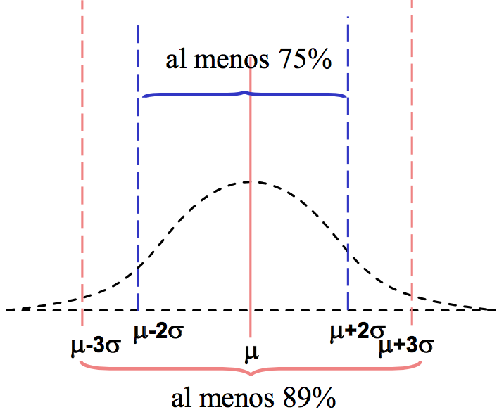

Sea

$m_k = E[X^k]$ el momento de order $k$ respecto al origen

$\mu_k = E[(X-\mu)^k]$ el momento de order $k$ respecto a la media

**Coeficiente de asimetría**

$CA = \frac{\mu_3}{\sigma^3}$

**Coeficiente de apuntamiento**

$CA_p = \frac{\mu_4}{\sigma^4}$ ó $\frac{\mu_4}{\sigma^4}-3$

### 2.0.2 Transformaciones lineales de variables aleatorias

Sea $Y = a + bX$

$E[Y] = a + b E[X]$ $Var[Y] = b^2 Var[X]$

# 3 Distribuciones de Probabilidad

## 3.1 Distribución Binomial $Bin(n,p)$

La variable aleatoria binomial, $X$, expresa el número de éxitos obtenidos en cada prueba del experimento.

- En cada prueba del experimento sólo son posibles dos resultados:
- La probabilidad del suceso A es constante, es decir, que no varía de una prueba a otra. Se representa por p.
- El resultado obtenido en cada prueba es independiente de los resultados obtenidos anteriormente.

La distribución Binomial es una distribución de probabilidad discreta, que describe el resultado de un experimento de $n$ pruebas independientes. Cada prueba se asume que tiene dos posibles valores. si la probabilidad de éxito es $p$, entonces la probabilidad de obtener $k$ éxitos de un experimento con $n$ pruebas independientes viene dado por la **función de masa de probabilidad**:

$$f(k,n,p) = \mbox{Pr}(X=k)=\binom{n}{k} p^k (1-p)^{n-k}, \quad k=0,1,2,...,n$$

La **función acumulativa de distribución** es:

$$F(k;n,p) = \mbox{Pr}(X\leq k) = \sum_{i=0}^{k}\binom{n}{i} p^i (1-p)^{n-i}$$

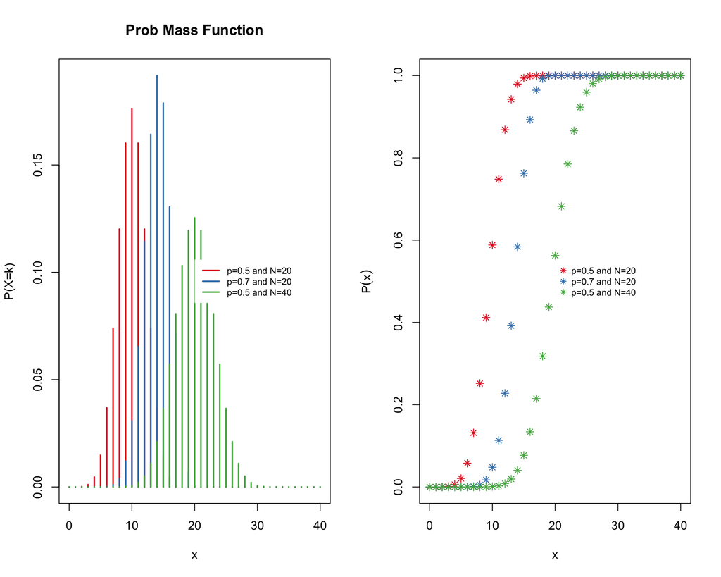

con *media* $np$ y *varianza* $np(1-p)$.

**Pregunta:**

Supongamos que en un examen de matemáticas hay 12 preguntas de respuesta múltiple. Cada una de las pregunras tiene 5 posibles respuestas de las cuáles tan sólo una de ellas es correcta.

- ¿Cuál es la probabilidad de obtener 4 o menos respuestas correctas si un estudiante contesta al azar?
- ¿Cuál es la probabilidad de que el alumno tenga 2 ó 3 respuestas correctas?

**Pregunta:**

Supongamos que la empresa *A* produce el producto *B* con una probabilidad de 0,005 de productos defectuosos. Supón que el prodcuto *B* se distribuye en lotes de 25 items. ¿Cuál es la probabilidad de que un lote seleccionado al azar tenga exactamente 1 producto defectuoso? ¿Cuál es la probabilidad de que un lote seleccionado al azar no tenga más de un item defectuoso?

**Soluciones aquí**

## 3.2 Distribución de Poisson $Pois(\lambda)$

La distribución de Poisson hace referencia a la modelización de situaciones en las que nos interesa determinar el número de hechos de cierto tipo que se pueden producir en un intervalo de tiempo o de espacio. Si el parámetro $\lambda$ es la media de sucesos por intervalo, la probabilidad de tener $k$ sucesos en el intervalo, se define como la función de probabilidad de masa:

$$\mbox{Pr}(\mbox{$k$ sucesos en el intervalo}) = \frac{\lambda^k e^{-\lambda}}{k!}$$

La **función de densidad acumulada** es
$$P(X\leq x ~|~\lambda ) = \frac{e^{-\lambda} \lambda ^x}{x!}\quad \mbox{for $x=0,1,2,...$}$$

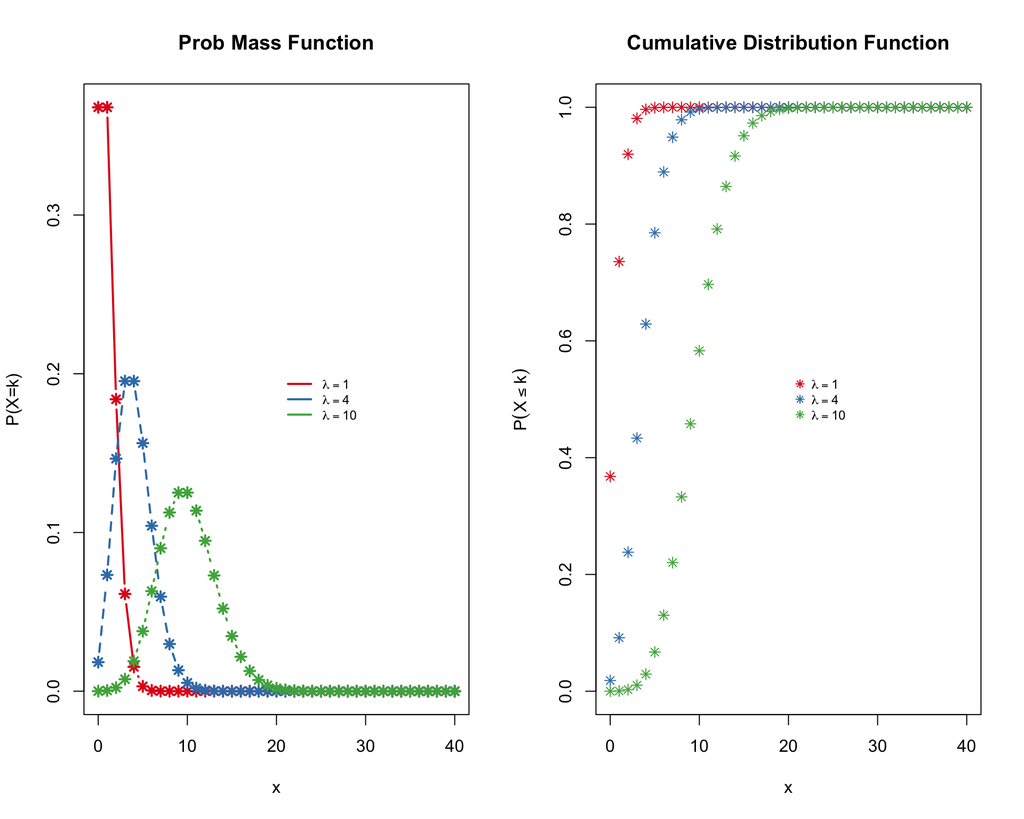

**Pregunta:**

Supongamos que el número de insectos en una plantación de un metro cuadrado, viene dada por una distribución de Poisson de media $\lambda= 10$. Calcula la probabilidad de encontrar exactamente $12$ insectos en una parcela de 1 $m^2$.

```
## [1] 0.09478033
```

**Pregunta:** Si hay 12 coches cruzando un puente por minuto en media. Calcula la probabilidad de encontrar 17 ó más coches cruzando el puente en un minuto cualquiera.

**Soluciones aquí**

## 3.3 Aproximación de la Binomial y la Poisson

**Ejemplo:**

El 5% de las bombillas de un árbol de navidad manufacturado por una compañia son defectuosas. El gerente del departamento de Control de calidad de la empresa está preocupado y ha seleccionado 100 bombillas de la cadena de montaje. Sea $X$ el número de bombillas defectuosas. ¿Cuál es la probabilidad de que la muestra de 100 bombillas tenga a lo sumo 3 bombillas defectuosas?

```r
p = 0.05
k = 3
n = 100
pbinom(k,size=n,prob=p)
```

```
## [1] 0.2578387
```

Se puede demostrar que la distribución Binomial se puede aproximar mediante la distribución de Poisson cuando $n$ es grande. Mediante la distribución de Poisson, la media es $\lambda = np$

```r
lambda <- n*p
sum(dpois(0:3,lambda))
```

```
## [1] 0.2650259
```

Esta aproximación es válida con $n$ grande y $p$ pequeño. En general, con $n \geq 20$ y $p\leq0.05$, o bien cuando $n\geq 100$ y $p\leq 0.10$.

## 3.4 Distribucion exponencial $Exp(\lambda)$

La distribución Exponencial mide la probabilidad de que una variable aleatoria que describe el tiempo entre eventos de un proceso de Poisson, es decir un proceso que ocurre de manera contínua e independiente a una tasa constante. Es un caso particular de la distribución Gamma y el análogo contínua de la distribución geométrica y tiene la propiedad de falta de memoria.

La funcion de densidad de probabilidad es
$$f(x;\lambda) = \lambda \exp(-\lambda x)$$

donde $\lambda>0$ es la tasa del evento (también conocido tasa de llegadas, tasa de transición etc …). Un variable aleatoria Exponencial: $x \in [0,\infty)$

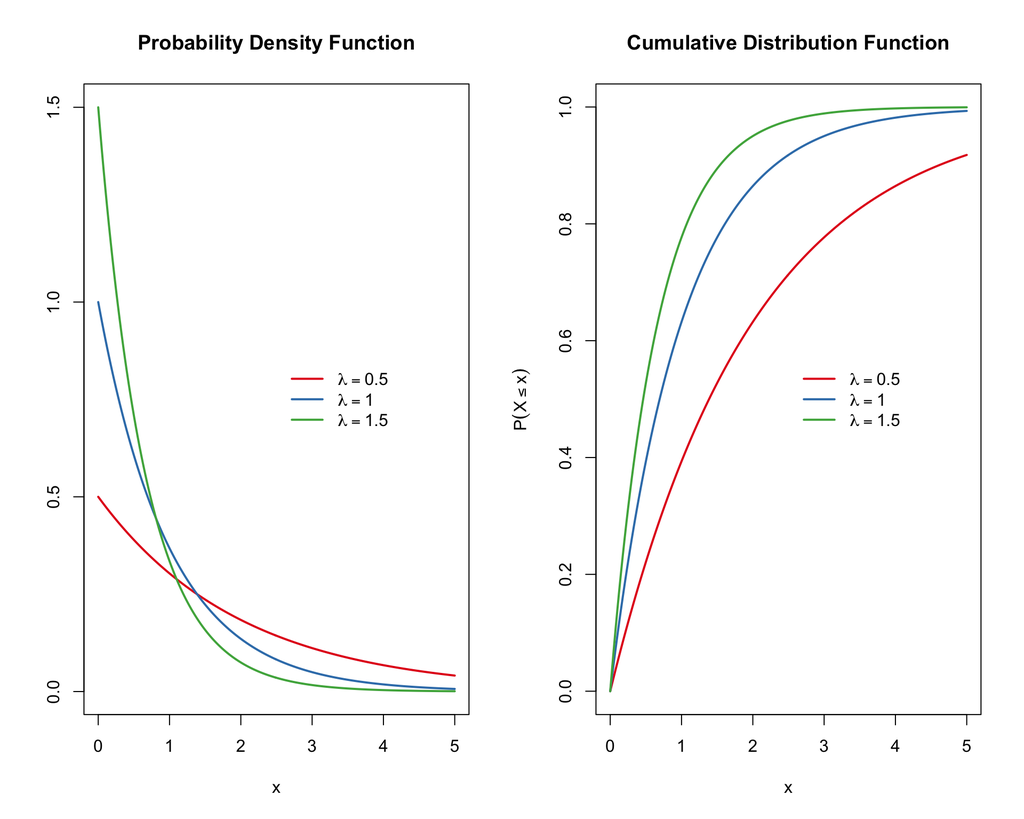

La función de distribución acumulada es
$$F(x) = \mbox{Pr}(X\leq x) =
\left\{
\begin{array}{lcc}
1- e^{-\lambda x} & & x\geq 0 \\
0 & & x < 0
\end{array}
\right.$$

La media $\mathbb{E}(X) = 1/\lambda$, y $\mathbb{V}ar(X) = 1/\lambda^2$.

**Pregunta:** Supongamos que la cantidad de tiempo que los clientes de un banco pasan en él se distribuye como una exponencial con media 10 minutos, por tanto $\lambda=1/10$.

- ¿Cuál es la probabilidad de que un cliente pase más de 15 minutos en el banco?
- ¿Cuál es la probabilidad de que un cliente pase más de 15 minutos en el banco dado que sigue en el banco después de 10 minutos?

**Soluciones aquí**

## 3.5 Distribución Normal $\mathcal{N}(\mu,\sigma^2)$

La función de densidad es

$$f(x | \mu,\sigma^2) = \frac{1}{\sqrt{2\sigma^2\pi}} e ^{-\frac{(x-\mu)^2}{2\sigma^2}},$$
donde

- $\mu$ es la media (tambien mediana y moda).
- $\sigma$ es la desviación estándar ($\sigma>0$).
- $\sigma^2$ la varianza.

El proceso de estandarización de la distribución Normal, consiste en transformar una variable $N(\mu,\sigma)$ en $N(0,1)$, i.e.
$$Z = \frac{X-\mu}{\sigma} \sim N(0,1)$$

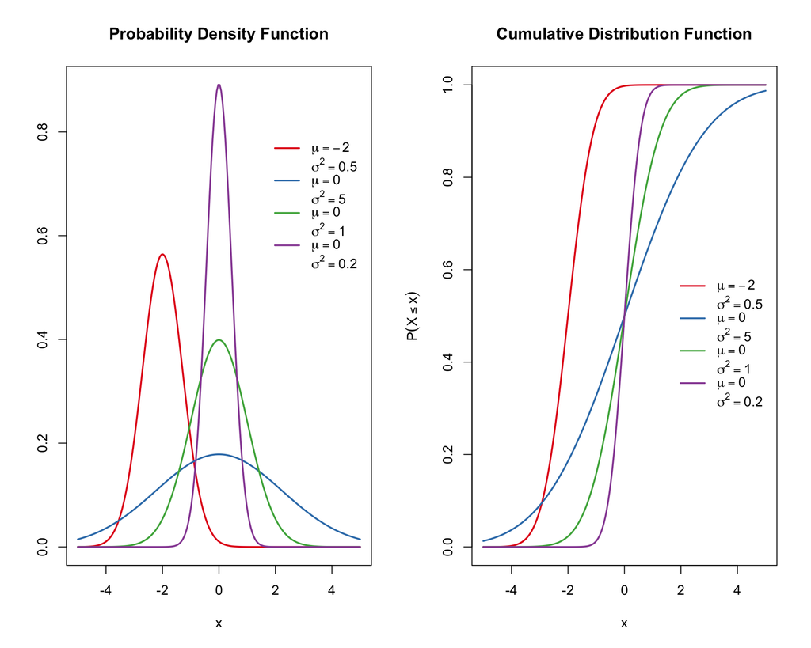

**Pregunta:**

Sea $X$ una variable aleatoria distribuida como una Normal con media $\mu = 30$ y desviación estandard $\sigma = 4$. Calcula

1. $P(x<40)$
2. $P(x>21)$
3. $P(30<x<35)$

**Pregunta:**

El acceso a una Universdad viene dado por un examen a nivel Nacional. Las puntuaciones de este examen se distribuyen mediante una distribución Normal con media 500 y desviación estandard de 100. Tomás quiere ser admitido a esta universidad y sabe que debe obtener una nota media superior al 70% de los estudiantes que hicieron el examen. Tomás sacó una nota de 585. ¿Será admitido?

**Soluciones aquí**